# Application 04

Anisha Shrestha

10/25/2019

```r
#### including BioC repo for dependencies
#install.packages("ggimage")

setRepositories(ind=1:2)
library(ggplot2)
library(ggimage)
library(ggtree)
```

##### What package are you using? State the name, whether it was on CRAN or GitHub, and provide the code you used for loading it.

> The package that I used here are: `ggimage`, `ggplot`. It is on CRAN package. For loading it, I installed the package with `install.pacakages("ggimage")` and in order to do further exploration under this pacakage we also have to set repositories. For that I used, `setRepositories(ind=1:2)` . After the installation, I can simply run the libraries `library("ggplot2")`, `library("emoGG")`, `library(rsvg)`, `library(ggtree)` and `library("ggimage")`. `rsvg` library is used for rendering svg images. `emoGG` library render emoji picture (png) and creat a layer, geom_emoji , to add emoji. `ggimage` supports image files and graphic objects to be visualized in `ggplot2` graphic system.

> The following object is masked from ‘package:ggimage’: (library(“emoGG”))

##### What are you doing with the package? Provide a narrative including code and output.

[figure not shown]

```r
set.seed(2017-02-21)
d <- data.frame(x = rnorm(10),
                y = rnorm(10),
                image = sample(c("https://www.r-project.org/logo/Rlogo.png",
                                 "https://jeroenooms.github.io/images/frink.png"),
                               size=10, replace = TRUE)
                )

ggplot(d, aes(x, y)) + geom_image(aes(image=image), size=.05)
```

> Similar as above replacing image in the image. Also Providing titles and axis to the graphs. Aspect ratio and rnorm: In order to keep control image size along with the grid and to randomly generate image in the plot.

[figure not shown]

```r
set.seed(2017-02-21)
example <- data.frame(x = rnorm(30),
                y = rnorm(30),
                image = sample(c("https://www.pngix.com/pngfile/big/17-170000_free-high-quality-cloud-rain-icon-transparent-background.png",

                                 "https://png2.cleanpng.com/sh/112318173171d4d8ad861cd68217c76e/L0KzQYm3V8ExN6d2f5H0aYP2gLBuTgBia15yedC2Y3BwgMb7hgIucZR0huU2Y3zsgH7okwQueJJohdN3LXnmf7B6TcVjPGY1fapvMUfkdoKBTskzQWo1SqU8MUW2QYO8UsM3P2EAT5D5bne=/kisspng-pac-man-computer-icons-clip-art-pacman-icons-5b450e8f17af18.929902331531252367097.png"),
                               size=10, replace = TRUE))
                ggplot(example, aes(x, y)) + geom_image(aes(image=image), size=.07)+labs(title= "Example 2 for Geom Image",y="Icon 1", x = "Icon 2")+theme_classic()
```

> one of `width` or `height` for specifying size.

[figure not shown]

```r
ggplot(d, aes(x, y)) + geom_image(aes(image=image), size=.1, by='height')+labs(title= "Specifying size",
 y="Icon 1", x = "Icon 2")+ theme_classic()
```

[figure not shown]

```r
ggplot(example, aes(x, y)) + geom_image(aes(image=image), size=.1, by='width')+labs(title= "Specifying size", y="Icon 1", x = "Icon 2")+ theme_classic()
```

> Showing Only one image

[figure not shown]

```r
ggplot(d, aes(x, y)) + geom_image(image=d$image[1])
```

[figure not shown]

```r
ggplot(example, aes(x, y)) + geom_image(image=example$image[1])
```

[figure not shown]

```r
d$size=seq(.05, .15, length.out=10)
ggplot(d, aes(x, y)) + geom_image(aes(image=image, size=I(size)))
```

[figure not shown]

```r
example$size=seq(.05, .15, length.out=10)
ggplot(example, aes(x, y)) + geom_image(aes(image=image, size=I(size)))
```

[figure not shown]

```r
ggplot(d, aes(x, y)) + geom_image(aes(image=image), color="firebrick")
```

> Exploratory Analysis

[figure not shown]

```r
ggplot(example, aes(x = x, y = 0.25, image = image)) + geom_image(size = 0.05, by="width") +scale_size_identity() +labs(title= "  ", y="Icon 1", x = "Icon 2")+ theme_minimal()
```

> Putting image inbetween the points. `images` We can simply specify the x & y aesthetics to locate the image into graphs and size will help with scaling if needed

[figure not shown]

```r
dta_img <- data.frame(x = 6, y = 3, image = 'https://www.r-project.org/logo/Rlogo.png')
ggplot(iris, aes(x = Sepal.Length, y = Petal.Length)) +
  geom_image(data = dta_img, aes(x, y, image = image), size = 0.1) +
  geom_point()
```

> Geom Pokemon inheritParams geom_pokemon return ggplot2 layer aes= aes mapping This is getting the pokemon icon `pikachu` and `tauros`.

[figure not shown]

```r
ggplot(d, aes(x, y)) + geom_pokemon(aes(image=ifelse(x>0, 'pikachu', 'tauros')), size=.2)
```

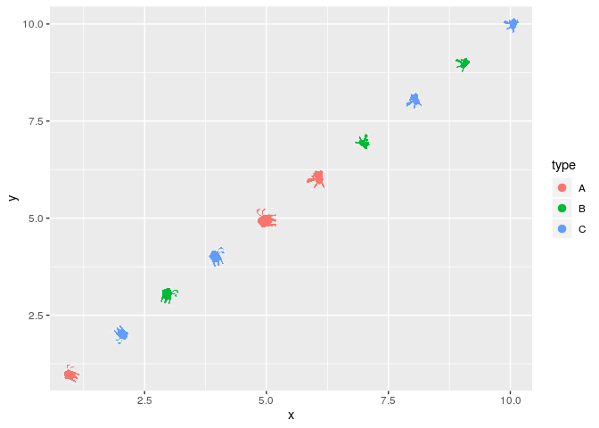

```r
#Example for Pokemon

set.seed(2018-12-11)
df  <-  data.frame(x=1:10, y=1:10,
                  type = sample(LETTERS[1:3], 10, replace=T),
                  angle = runif(10, 0, 360))

options(ggimage.keytype = "point")
ggplot(df, aes(x, y, colour=type, angle=angle)) +
    geom_pokemon(aes(image=ifelse(x>5, 'pikachu', 'tauros')))
```

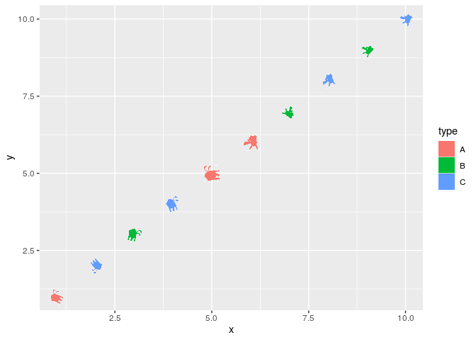

```r
options(ggimage.keytype = "rect")
ggplot(df, aes(x, y, colour=type, angle=angle)) +
    geom_pokemon(aes(image=ifelse(x>5, 'pikachu', 'tauros')))
```

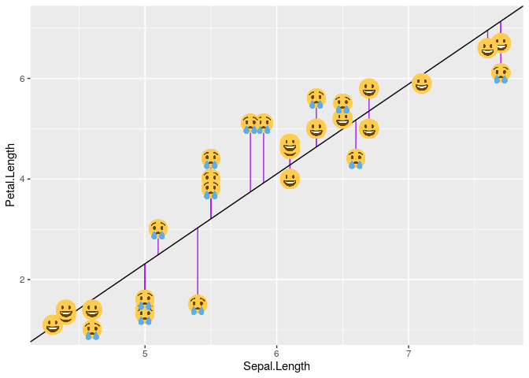

```r
set.seed(123)
iris2 <- iris[sample(1:nrow(iris), 30),]
model <- lm(Petal.Length ~ Sepal.Length, data=iris2)
iris2$fitted <- predict(model)

ggplot(iris2, aes(x = Sepal.Length, y = Petal.Length)) +
  geom_linerange(aes(ymin = fitted, ymax = Petal.Length),
                 colour = "purple") +
  geom_abline(intercept = model$coefficients[1],
              slope = model$coefficients[2]) +
    geom_emoji(aes(image = ifelse(abs(Petal.Length-fitted) > 0.5, '1f622', '1f600')))
```

> geom_flag geom layer for using flag image title geom_flag return flag vector scale fill mannual values shows three types of medel with respective color. The `ggimage package` is able to create a geom layer for an image. A dataframe with all the country’s flag and count are stored in `f` and then in the geom_flag() function specifies the image argument.

[figure not shown]

```r
f <- system.file("extdata/medals.txt", package="ggimage")
medals <- read.table(f, header=TRUE)
p <- ggplot(medals, aes(Country, count)) + geom_col(aes(fill = medal), width = .8)

p + geom_flag(y = -2, aes(image = code)) +
    coord_flip() + expand_limits(y = -2)  +
    scale_fill_manual(values = c("Gold" = "gold", "Bronze" = "#cd7f32", "Silver" = "#C0C0C0"))+labs(title= "Geom Layer For using Flag Image")+ theme_minimal()
```

> geom_icon Here, we have used rsvg library, and plotted 3 icon with replacement.

[figure not shown]

```r
library(rsvg)
d$icon=sample(c('ios-power', 'ios-wifi', 'ios-pie'), 10, replace=TRUE)
ggplot(d, aes(x,y)) + geom_icon(aes(image=icon))
```

```r
library(tibble)
dd <- data.frame(x=LETTERS[1:3], y=1:3)
pie <- ggplot(dd, aes(x=1, y, fill=x)) + geom_bar(stat="identity", width=1) + coord_polar(theta="y") +
    theme_void() + theme(legend.position="none") + theme_transparent()

df <- data_frame(x = sample(2:9),
                 y = sample(2:9),
                 width = sample(seq(0.5, 3, length.out=length(x))),
                 pie = list(pie))
```

> geom_subview title geom_subview importFrom ggplot2 annotation_custom x position of subview. This parameter works if mapping and data is not provided y position of subview. This parameter works if mapping and data is not provided subview to plot, if not provided in data and specify by mapping

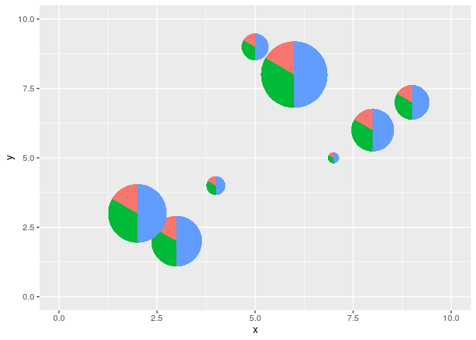

```r
p <- ggplot(data=data.frame(x=c(0, 10), y=c(0, 10)), aes(x, y))+geom_blank()
p + geom_subview(aes(x=x, y=y, subview=pie, width=width, height=width), data=df)
```

> geom layer for using Twitch emotes

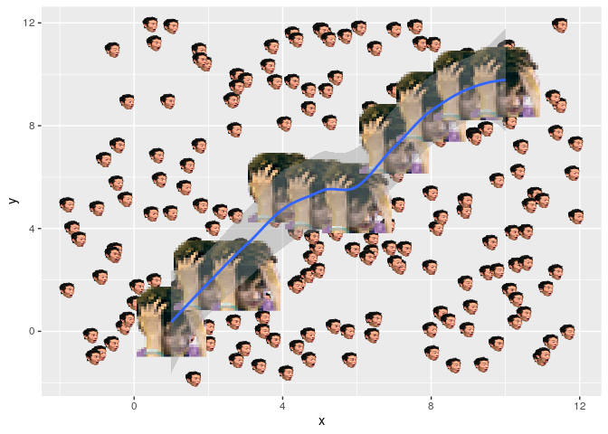

```r
set.seed(1)
x <- 1:10
y <- x + rnorm(10, sd = 1)
notlikethis <- data.frame(x = x, y = y)
n_pals      <- 200
pals        <- data.frame(
  x = runif(n_pals, -2, 12), y = runif(n_pals, -2, 12),
  pal = sample(c("wutface", "kappa", "pogchamp"), size = n_pals, replace = TRUE)
)

ggplot(notlikethis, aes(x = x, y = y)) +
  geom_twitchemote(data = pals,
                   aes(image = 'pogchamp'), size = 0.03, alpha = 0.3) +
  geom_twitchemote(aes(image = 'notlikethis'), size = 0.15) +
  geom_smooth()
```

> The layers defined in ggimage can be directly applied to ggtree to annotate phylogenetic tree using local/online image files. query phylopic to get `uid` from scientific name: phylopic_uid() This function reads a file which contains one or several trees in parenthetic format known as the Newick or New Hampshire format. Uses the viridis color scale. add tip label layer: geom_tiplab , arguement like, linetype, linesize, ajust etc.

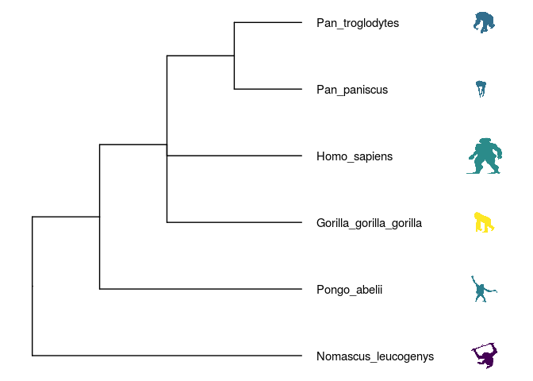

```r
newick <- "((Pongo_abelii,(Gorilla_gorilla_gorilla,(Pan_paniscus,Pan_troglodytes)Pan,Homo_sapiens)Homininae)Hominidae,Nomascus_leucogenys)Hominoidea;"

tree <- read.tree(text=newick)

idlist <- ggimage::phylopic_uid(tree$tip.label)
ids <- sapply(idlist, function(x) x[1,1])

d <- data.frame(label = tree$tip.label, uid = ids,
                body_mass = c(52, 114, 47, 45, 58, 6))

p <- ggtree(tree) %<+% d +
  geom_tiplab(aes(image=uid, colour=body_mass), geom="phylopic", offset=2.5) +
  geom_tiplab(aes(label=label), offset = .2) + xlim(NA, 7) +
  scale_color_viridis_c()
p
```